# Classification tree

# About classification trees

A classification tree uses different predictors to sequentially sort observations into “purer” categories of outcomes, with the goal of knowing which labels and/or cut-off values of predictors lead to an outcome “Yes” or “No”. This different from logistic regression, which uses a weighted combination of predictors to calculate a probability of an outcome being “Yes” or “No”.

**Advantages**:  
Compared to logistic regression, the information from categorical and cut-off values is easier to interpret and may be practically useful. (A toy example: In a sample of 100 where 20 people bought hearing aids and 80 did not, PTA > 40 and HHIE > 20 correctly identified 19 of those 20 who bought hearing aids. It’s easier to use this information than knowing, say, that every 1-point increase in PTA led to a 3% increase in the odds of someone buying a hearing aid.) Trees can also work with missing data by using “surrogate variables” when there is missing data in a predictor variable, whereas logistic regression requires all variables to be complete.

**Disadvantages**:  
Trees are not as “robust” as some other models; i.e., a small change in the data can lead to a big change in the model, because earlier branches in the sequence will have flow-on effects. Simplicity can also be its downfall. First, using labels and cut-offs (“straight lines”, so to speak) to classify cases isn’t flexible for fitting complex data and can make trees less accurate than some other types of models. Second, allowing fewer branches to grow makes a tree easier to interpret, but it is likely to classify fewer cases correctly.

# Data and case weights

All participants included in this analysis had PTA > 25 in the better ear, with complete data across the 28 predictors of interest (n=753). Because ‘No’ cases outnumbered ‘Yes’ cases almost 4:1, I weighted ‘No’ cases (149/604 = 0.246688) more lightly than ‘Yes’ cases (1.0), so that the model would not be biased towards ‘No’ cases.

# Pruning a classification tree

A “full” classification tree is one that is allowed to grow without any restriction; in other words, the model continues to sort observations at each node without any minimum criterion for improvement, ending only when there are less than 20 cases in a node (this number is one parameter that can be specified; *minsplit* = 20 is the default in *rpart*).

A full tree is hard to interpret, and likely would not generalize to other data. To decide how to prune back a complex tree, a standard method is to pick a range of complexity parameters (CP) and see how well the tree classifies cases at different levels of complexity. A low CP allows the tree to split more whenever there’s a small improvement, while a high CP requires a large improvement before allowing a further split. So low CP’s lead to more complex trees, while high CP’s lead to simpler trees. The best tree has the highest CP with the best accuracy, i.e., simple but accurate. The plot below shows the accuracy of models of our data, built using a typical range of CP values. (There is an “average” and “SE” for accuracy because there’s a 5-fold cross-validation procedure; the model is built on 5 subsets of the data.)

Judging by overall accuracy, the CP value leading to the best model is 0.02, which gives a simple tree with 3 splits. However…

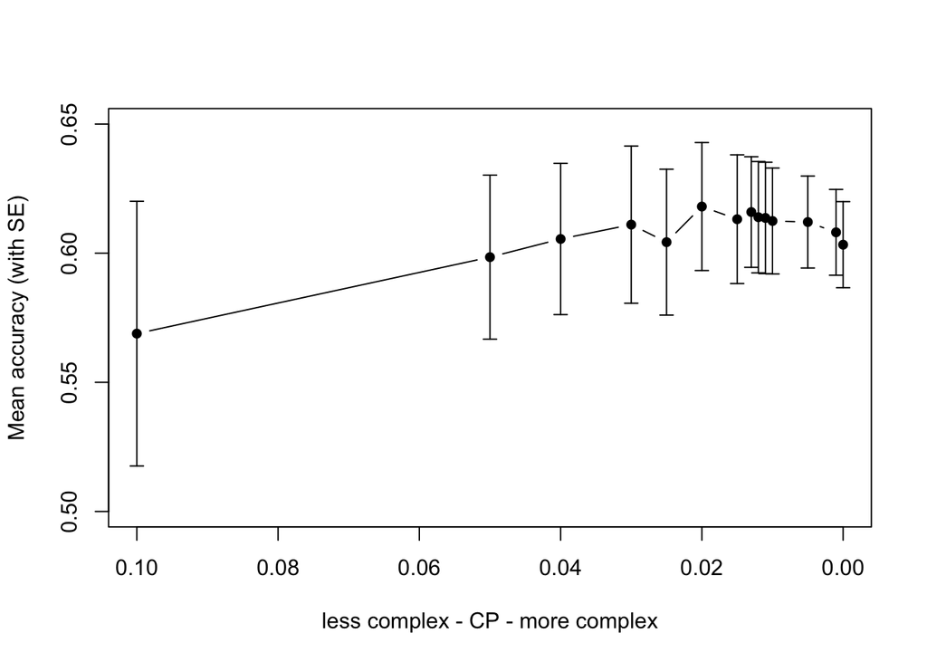

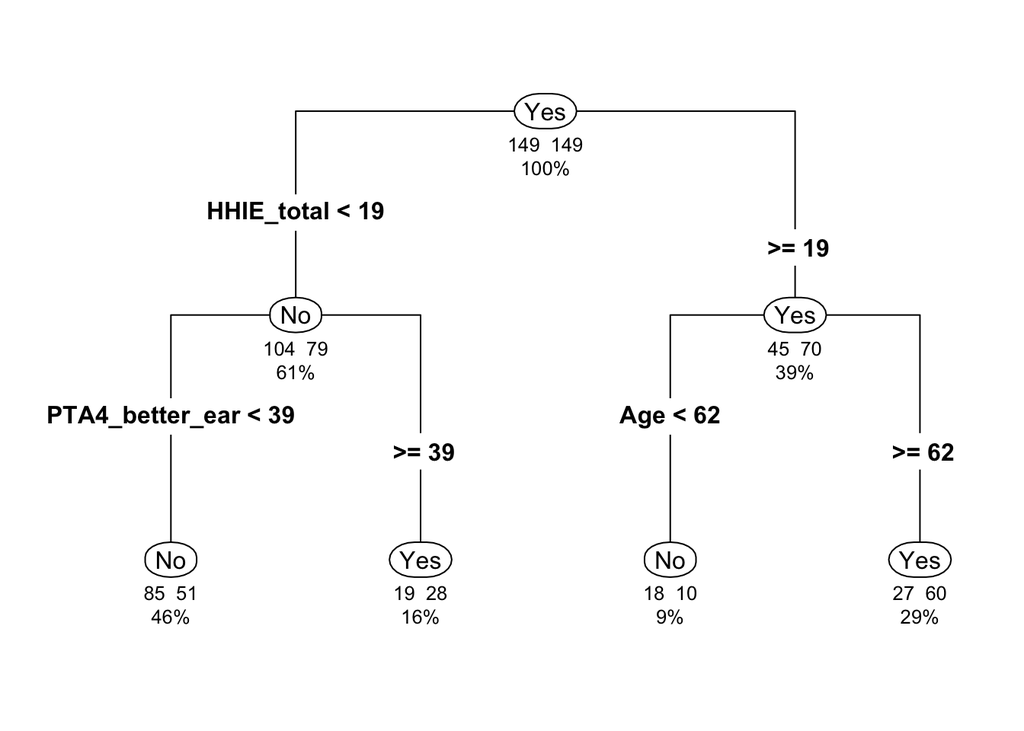

# Evaluating sensitivity and specificity (AUC)

…looking beyond overall accuracy into sensitivity (correctly identified ‘Yes’ cases) and specificity (correctly identified ‘No’ cases):

Going from a 3- or 5-split tree to a 12-split tree means a 23-point increase in sensitivity from 59% to 82%, for a relatively small trade-off of 8 to 12 points lower specificity. (Note that the x-axis scale is reversed to show a typical ROC plot; reversed Specificity is basically the False Positive Rate.)

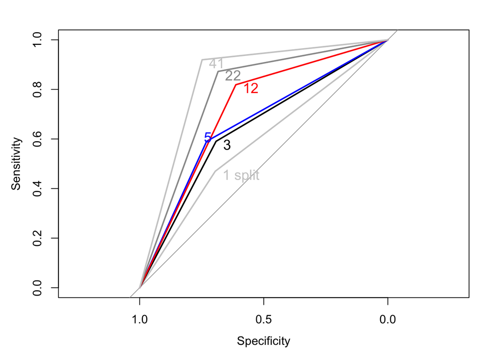

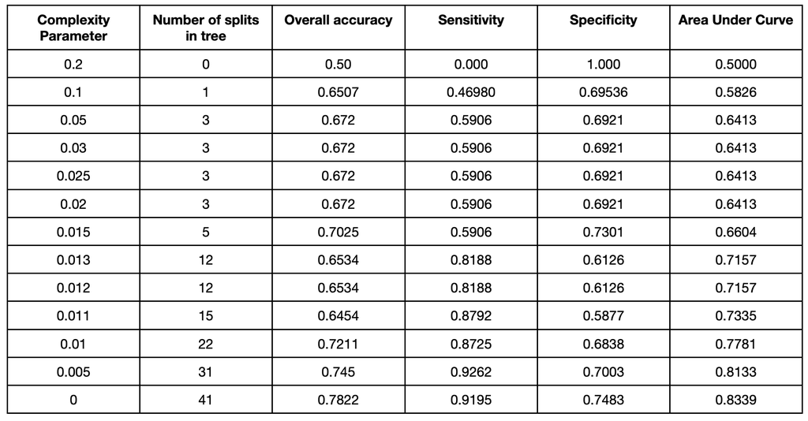

(See the new [12-split tree diagram](https://huiwen-goy.github.io/connect1-stigma/tree_cp013.pdf), and the previous tree that was limited to a [maximum depth of 4](https://huiwen-goy.github.io/connect1-stigma/tree_mdepth4.pdf) splits.)

# Variable importance

In this case, variable importance measures how much each variable increased the proportion of correctly classified cases, relative to the other variables. In the plot below, variable importance is scaled across variables so that the total sums to 100%; e.g. of all the cases that were switched from an incorrect group to the correct group by this model, Age accounted for 27% for them.

*(Technical note: maxcompete = FALSE and maxsurrogate = 0, to look only at the variables involved in the primary splits.)*

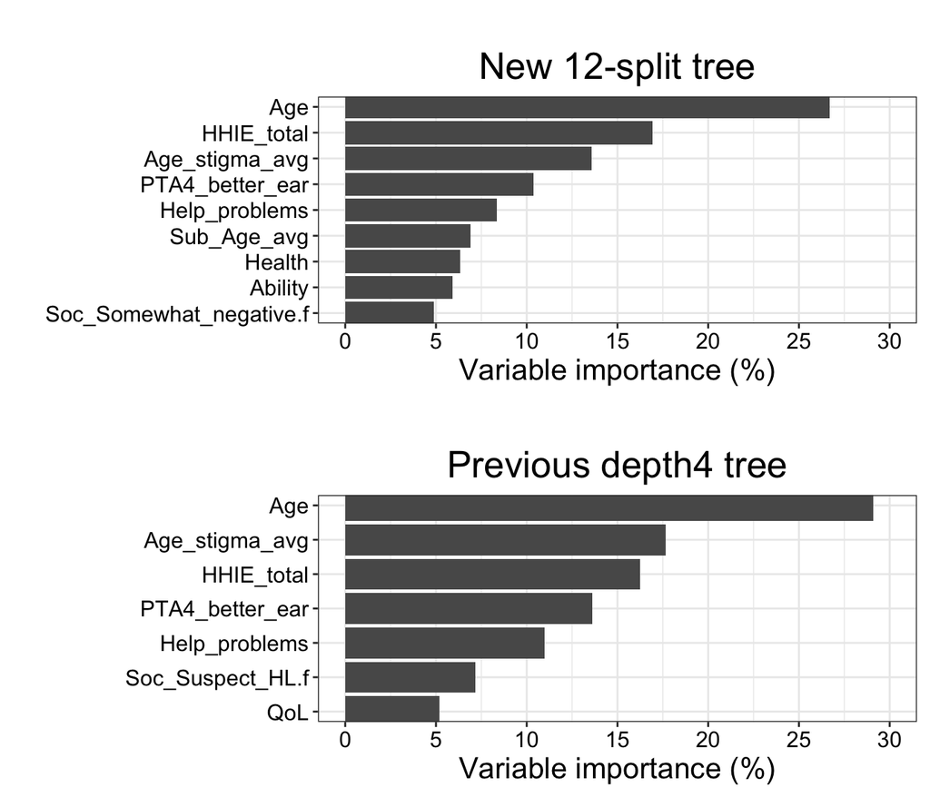

**Stability of variable importance**

To check how the tree model changes with different subsets of the data, 5 different trees were constructed using the same parameters, dropping out a different 20% “slice” of the data each time. The proportion of ‘Yes’ and ‘No’ cases was kept constant in all subsets of the data.

‘Age’ was always in the top three variables (5/5), while ‘HHIE’ was almost always in the top three (4/5). ‘PTA’, ‘Age Stigma’ and ‘Hearing Aid Stigma’ fluctuated much more in their rankings.

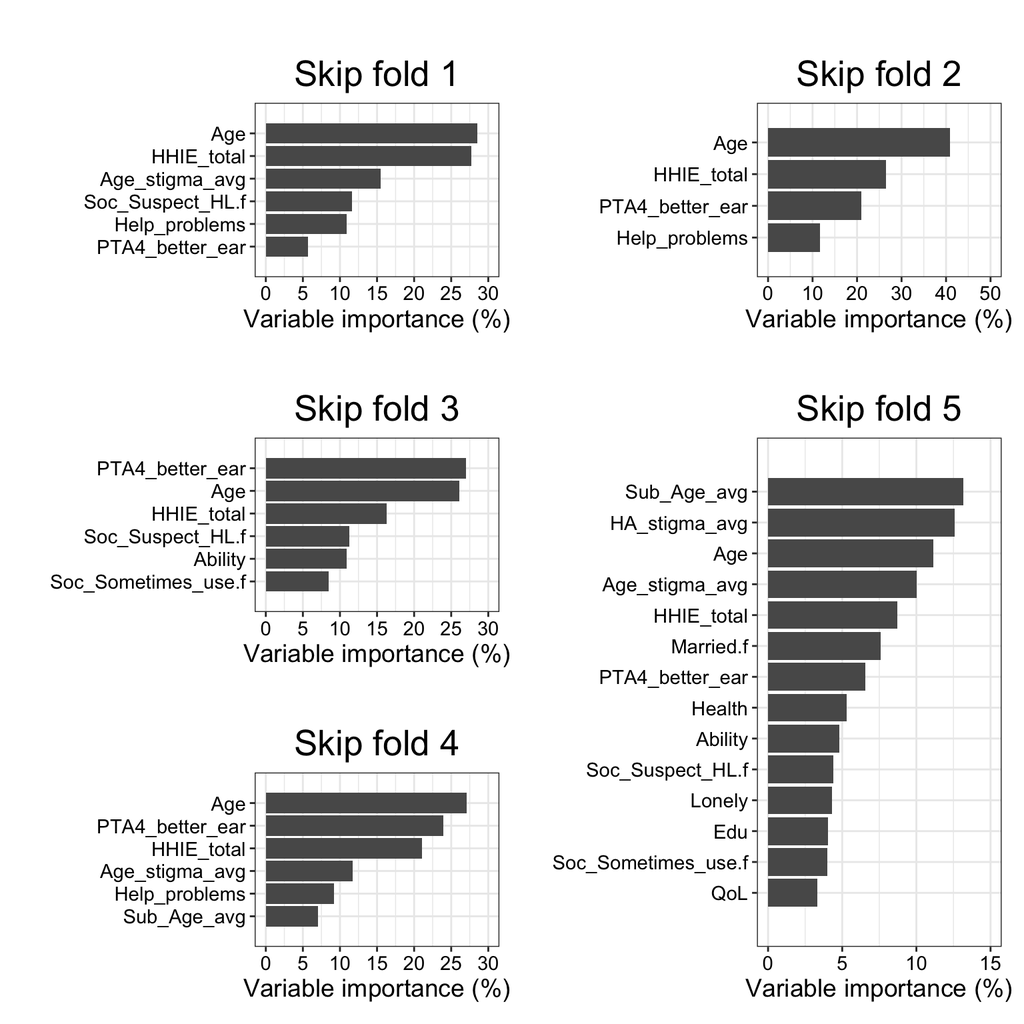

# Takeaways

1. A standard method of tree pruning based only on accuracy suggests a 3-split tree is best. However, looking at sensitivity and specificity, a 12-split tree is much more sensitive (82%) than a 3-split tree (59%), and this gain of +23 points is offset by a relatively small decrease of -8 points in specificity (i.e. a low impact on false positives).
2. For a 12-split tree, a measure of variable importance shows that Age Stigma matters almost as much as HHIE, with Age, HHIE, and Age Stigma in the 1st, 2nd, and 3rd ranks.
3. Checking on the stability of the tree model by dropping out different subsets of data, Age and HHIE are stable effects, but the effects of other variables fluctuate a lot.